# Model fitting and prediction in glm.R

This file states the fitting and prediction step of each family in `workflow/scripts/lib/glm.R` as formal models. Each section names the functions that implement it.

Two rules use this file:

- Rule `fit` calls `fit_model_family()` once for each training set. The fit holds the posterior and the LOO predictive of each training point.
- Rule `score` calls `predict_new_family()` on the pooled test set. Then it scores the LOO predictive and the test predictive with `lib/scores.R`.

# Notation

| Symbol | Argument | Default | Meaning |
| --- | --- | --- | --- |
| $X$ | `X` |  | $n \times d$ design matrix of the training set |
| $y$ | `y` |  | training outcomes |
| $\tilde x$ | a row of `X_new` |  | covariates of a new point |
| $d$ | `ncol(X)` |  | number of coefficients |
| $\sigma_0$ | `prior_sd` | `PRIOR_SD` = 5 | prior SD of the GLM coefficients |
| $\hat\beta$ | `beta_hat` |  | posterior mode (Gaussian: least squares) |
| $V$ | `V` |  | posterior covariance, see each family |
| $-i$ |  |  | the training set without observation $i$ |

## Models A and B

`model_columns(model, n_dim)` selects the columns of $X$:

- Model A uses columns $1, \dots, D - 1$. It omits the last covariate.
- Model B uses all $D$ columns.

All formulas below hold for both models. Only $X$ changes.

## What a fit returns

Each `fit_model_<family>()` returns a list with:

- the posterior of $\beta$, as $\hat\beta$ and $V$;
- `loo`, the LOO predictive $p(y_i \mid y_{-i})$ for each $i = 1, \dots, n$.

Each `predict_new_<family>()` returns the test predictive $p(\tilde y \mid y)$ for each row of `X_new`. The LOO predictive and the test predictive have the same form, so `lib/scores.R` scores both with one function.

# Gaussian model

Functions: `fit_model_gaussian()`, `loo_predictive_gaussian()`, `predict_new_gaussian()`.

## Model and prior

$$\begin{aligned}
y_i \mid \beta, \sigma^2 &\sim \mathcal{N}(x_i^\top \beta,
\sigma^2), \\
p(\beta) &\propto 1, \\
p(\sigma^2) &\propto 1 / \sigma^2.
\end{aligned}$$

The noise variance $\sigma^2$ is unknown. Its prior is uniform on $\log \sigma^2$. These priors are the ones of Sivula et al. (2025).

## Posterior

The posterior is exact. No approximation is used.

$$\hat\beta = (X^\top X)^{-1} X^\top y, \qquad
V = (X^\top X)^{-1}.$$

$\beta \mid y$ is a multivariate $t$ with $n - d$ degrees of freedom, location $\hat\beta$ and scale $s^2 V$, where

$$s^2 = \frac{\lVert y - X \hat\beta \rVert^2}{n - d}.$$

`fit$V` stores $(X^\top X)^{-1}$ without the factor $s^2$.

## Test predictive

$$\tilde y \mid y \sim
t_{n-d}\!\left(\tilde x^\top \hat\beta,\;
s^2 (1 + \tilde x^\top V \tilde x)\right).$$

`predict_new_gaussian()` returns `list(mu, scale, df)`.

## LOO predictive

The LOO predictive is exact. It needs no refit. With the hat values $h_i = x_i^\top (X^\top X)^{-1} x_i$ and the residuals $e_i = y_i - x_i^\top \hat\beta$ of the full fit:

$$\begin{aligned}
y_i - x_i^\top \hat\beta_{-i} &= \frac{e_i}{1 - h_i}, \\
1 + x_i^\top (X_{-i}^\top X_{-i})^{-1} x_i &= \frac{1}{1 - h_i}, \\
\mathrm{RSS}_{-i} &= \mathrm{RSS} - \frac{e_i^2}{1 - h_i}.
\end{aligned}$$

So the LOO predictive of $y_i$ has

- location $\mu_i = y_i - e_i / (1 - h_i)$,
- scale$^2$ $= s^2_{-i} / (1 - h_i)$ with $s^2_{-i} = \mathrm{RSS}_{-i} / (n - 1 - d)$,
- $n - 1 - d$ degrees of freedom.

`loo_predictive_gaussian()` computes $h_i$ and $e_i$ from one QR decomposition.

# Binomial (Bernoulli) model

Functions: `laplace_approx()`, `mean_weight()`, `log_lik()`, `predictive_prob()`, `loo_predictive_binomial()`, `fit_model_binomial()`, `predict_new_binomial()`.

## Model and prior

$$\begin{aligned}
y_i \mid \beta &\sim
\operatorname{Bernoulli}\!\left(\operatorname{logit}^{-1}(x_i^\top
\beta)\right), \\
\beta &\sim \mathcal{N}(0, \sigma_0^2 I), \qquad \sigma_0 = 5.
\end{aligned}$$

A flat prior gives an improper posterior under separation. Separation is frequent at small $n$. So the prior is weakly informative, not flat.

## Posterior: Laplace approximation

No closed form exists. `laplace_approx(family = "binomial")` uses a Laplace approximation:

$$\beta \mid y \approx \mathcal{N}(\hat\beta, V).$$

**Mode.** Newton’s method (penalised IRLS) maximises the log posterior

$$\ell(\beta) = \sum_i \left[ y_i \eta_i - \log(1 + e^{\eta_i}) \right]
- \frac{\lVert \beta \rVert^2}{2 \sigma_0^2},
\qquad \eta_i = x_i^\top \beta.$$

With $p_i = \operatorname{logit}^{-1}(\eta_i)$, $W = \operatorname{diag}(p_i (1 - p_i))$ and $P = I / \sigma_0^2$, one step is

$$\beta \leftarrow \beta + H^{-1} \left[ X^\top (y - p) - P \beta \right],
\qquad H = X^\top W X + P.$$

If a step decreases $\ell(\beta)$, it is halved until $\ell(\beta)$ does not decrease, at most 30 times. A decrease of the size of the rounding error does not count. Without the halving, a large count (an outlier) makes the first Poisson step overshoot to $\eta \approx 60$. Each later step then lowers $\eta$ by only 1.

The iteration stops when the largest full step is below $10^{-10}$. After 100 steps without convergence, `laplace_approx()` warns and returns `NA`. The NA makes every measure of the trial NA, and `summarise.R` drops the trial. The weights have a floor of $10^{-10}$, so $H$ stays positive definite.

**Covariance.** $V = H^{-1}$, with $H$ evaluated at $\hat\beta$.

## Test predictive

The test predictive depends on $\beta$ only through $\tilde\eta = \tilde x^\top \beta$. Under the Laplace posterior, $\tilde\eta \sim \mathcal{N}(m, s^2)$ with

$$m = \tilde x^\top \hat\beta, \qquad s^2 = \tilde x^\top V \tilde x.$$

So the test predictive probability of $\tilde y = 1$ is a one-dimensional integral:

$$p = \Pr(\tilde y = 1 \mid y)
= \int \operatorname{logit}^{-1}(\eta) \, \mathcal{N}(\eta \mid m,
s^2) \, d\eta.$$

`predictive_prob()` computes it with the trapezoid rule over the standardised $t = (\eta - m) / s$:

- range $t \in [-9, 9]$ (`QUAD_RANGE`),
- step $h = 0.5 / \max(1, \max_j s_j)$ (`QUAD_STEP`), with the largest $s$ over all rows, so all rows share one grid.

The step shrinks as $s$ grows, because the poles of $\operatorname{logit}^{-1}(m + s t)$ come closer to the real axis. `predict_new_binomial()` returns `list(p)`.

## LOO predictive

The LOO predictive is exact with respect to the Laplace model. For each $i$, `loo_predictive_binomial()`:

1. refits `laplace_approx()` on $(X_{-i}, y_{-i})$, with a warm start at the full-data mode $\hat\beta$;
2. sets $m_i = x_i^\top \hat\beta_{-i}$ and $s_i^2 = x_i^\top V_{-i} x_i$;
3. computes $p_i$ with `predictive_prob(m_i, s_i)`.

This is $n$ refits for each training set.

# Poisson model

Functions: `laplace_approx()`, `mean_weight()`, `log_lik()`, `pois_nodes()`, `pois_k_max()`, `predictive_pmf()`, `predictive_count_dens()`, `loo_predictive_poisson()`, `fit_model_poisson()`, `predict_new_poisson()`.

## Model and prior

$$\begin{aligned}
y_i \mid \beta &\sim \operatorname{Poisson}\!\left(e^{x_i^\top
\beta}\right), \\
\beta &\sim \mathcal{N}(0, \sigma_0^2 I), \qquad \sigma_0 = 5.
\end{aligned}$$

## Posterior: Laplace approximation

`laplace_approx(family = "poisson")` uses the same Newton method as the binomial model, with the log link. With $\mu_i = e^{\eta_i}$ and $W = \operatorname{diag}(\mu_i)$:

$$\ell(\beta) = \sum_i \left[ y_i \eta_i - e^{\eta_i} \right]
- \frac{\lVert \beta \rVert^2}{2 \sigma_0^2},
\qquad
\beta \leftarrow \beta + H^{-1} \left[ X^\top (y - \mu) - P \beta
\right],$$

with $H = X^\top W X + P$ and $V = H^{-1}$ at $\hat\beta$.

- In $\mu$ and $W$, $\eta$ is capped at 30 (`ETA_MAX`), so $e^{\eta}$ cannot overflow.
- `log_lik()` does not cap $\eta$. A step to a huge $\eta$ then gets a low $\ell(\beta)$, and the step is halved.
- The weights have a floor of $10^{-10}$.

## Test predictive

Again $\tilde\eta \sim \mathcal{N}(m, s^2)$ with $m = \tilde x^\top \hat\beta$ and $s^2 = \tilde x^\top V \tilde x$. So the rate $\lambda = e^{\tilde\eta}$ is lognormal, and the test predictive is a Poisson–lognormal mixture:

$$\Pr(\tilde y = k \mid y)
= \int \operatorname{Poisson}(k \mid e^{\eta}) \,
\mathcal{N}(\eta \mid m, s^2) \, d\eta,
\qquad k = 0, 1, 2, \dots$$

`predict_new_poisson()` returns only `list(m, s)`. `lib/scores.R` then evaluates the integral as each score needs it:

- **elpd:** `predictive_count_dens()` evaluates the integral at the observed count only. It needs no count grid.
- **sqe, ae:** they use the exact predictive mean $\mathbb{E}[\tilde y] = e^{m + s^2 / 2}$.
- **rps, srps:** `predictive_pmf()` builds the pmf on $k = 0, \dots, k_{\max}$. `pois_k_max()` doubles $k_{\max}$ until the tail mass is below $10^{-6}$ (`POIS_TAIL`), up to 20000 (`POIS_K_MAX`). The pmf is then renormalised.

The quadrature is the trapezoid rule over $t \in [-5, 5]$ (`QUAD_RANGE_POIS`). The step shrinks with $s$ and with the largest count, because $\operatorname{Poisson}(k \mid e^{m + s t})$ gets narrower in $t$ as $k$ grows. `pois_nodes()` divides the weights $\phi(t)$ by their sum, so the weights sum to one.

## LOO predictive

`loo_predictive_poisson()` follows the binomial steps 1 and 2: one refit for each $i$, warm started at $\hat\beta$. It returns `list(m, s)`.

# Summary

|  | Gaussian | Binomial | Poisson |
| --- | --- | --- | --- |
| Prior on $\beta$ | flat | $\mathcal{N}(0, 5^2 I)$ | $\mathcal{N}(0, 5^2 I)$ |
| Posterior | exact | Laplace | Laplace |
| Mode | least squares | Newton (IRLS) | Newton (IRLS) |
| Predictive | $t$ | $\mathbb{E}[\operatorname{logit}^{-1}(\eta)]$, quadrature | Poisson–lognormal, quadrature |
| LOO | closed form, no refit | $n$ refits | $n$ refits |
| Returned form | `list(mu, scale, df)` | `list(p)` | `list(m, s)` |

## Is the Laplace approximation good enough?

At small $n$, the binomial posterior is skewed. Then the Laplace predictive differs from the exact Bayesian predictive. This does not bias the study:

- The study checks whether LOO estimates the test score of *a* predictive. That predictive does not need to be the exact posterior.
- The LOO predictive and the test predictive use the same approximation.

# One fit for each family

The chunk fits model B to one data set of each family, with no outlier, for $n = 64$ and $n = 1024$. The smaller set is the first 64 rows of the larger one. It prints the true $\beta$, the posterior mode $\hat\beta$ and the fields of the LOO predictive. The Poisson data use the scaled $\beta$ of `make_data_poisson()`: the slopes times `POIS_SCALE` = 0.5, and the intercept `POIS_INTERCEPT` = 1.

```r
beta <- make_beta_coeff(1)
beta_pois <- beta * POIS_SCALE
beta_pois[1] <- POIS_INTERCEPT
beta_true <- list(gaussian = beta, binomial = beta, poisson = beta_pois)
n_grid <- c(64, 1024)

fmt <- function(b) paste(sprintf("%5.2f", b), collapse = ", ")
for (fam in names(beta_true)) {
  set.seed(1)
  d <- make_data_family(fam, 1, max(n_grid), max(n_grid), beta, out_dev = 0)
  cat(sprintf("%-8s true            = (%s)\n", fam, fmt(beta_true[[fam]])))
  for (n in n_grid) {
    fit <- fit_model_family(fam, d$X[seq_len(n), , 1], d$y[seq_len(n), 1])
    cat(sprintf("%-8s beta_hat n=%-4d = (%s) | loo: %s\n", "", n,
                fmt(fit$beta_hat), paste(names(fit$loo), collapse = ", ")))
  }
}
```

```
## gaussian true            = ( 0.00,  1.00,  1.00)
##          beta_hat n=64   = (-0.10,  0.93,  1.18) | loo: mu, scale, df
##          beta_hat n=1024 = ( 0.03,  1.02,  1.01) | loo: mu, scale, df
## binomial true            = ( 0.00,  1.00,  1.00)
##          beta_hat n=64   = (-0.19,  0.93,  1.03) | loo: p
##          beta_hat n=1024 = (-0.00,  1.06,  0.99) | loo: p
## poisson  true            = ( 1.00,  0.50,  0.50)
##          beta_hat n=64   = ( 1.06,  0.56,  0.41) | loo: m, s
##          beta_hat n=1024 = ( 1.01,  0.50,  0.50) | loo: m, s
```

# How noisy is one fit?

One data set gives one draw of $\hat\beta$. The chunk below repeats the fit on 200 data sets of each family, for $n = 16, 32, \dots, 1024$. Each smaller set is the first $n$ rows of the largest one.

```r
n_sets <- 200
n_seq <- 2^(4:10)
coef_names <- c("intercept", "slope 1", "slope 2 (beta_t)")

# Posterior mode and posterior SD of each coefficient. The Gaussian
# posterior is a t, so its SD has the factor df / (df - 2).
posterior <- function(fam, X, y) {
  if (fam == "gaussian") {
    f <- fit_model_gaussian(X, y)
    sd <- sqrt(f$s2 * diag(f$V) * f$df / (f$df - 2))
  } else {
    f <- laplace_approx(X, y, fam)
    sd <- sqrt(diag(f$V))
  }
  list(beta_hat = f$beta_hat, sd = sd)
}

sim <- list()
for (fam in names(beta_true)) {
  set.seed(1)
  d <- make_data_family(fam, n_sets, max(n_seq), max(n_seq), beta,
                        out_dev = 0)
  est <- sd <- array(NA_real_, c(length(n_seq), n_sets, length(beta)))
  for (a in seq_along(n_seq)) {
    k <- seq_len(n_seq[a])
    for (s in seq_len(n_sets)) {
      p <- posterior(fam, d$X[k, , s], d$y[k, s])
      est[a, s, ] <- p$beta_hat
      sd[a, s, ] <- p$sd
    }
  }
  sim[[fam]] <- list(est = est, sd = sd)
}
```

## Spread of $\hat\beta$ over data sets

The band holds 95% of the 200 estimates. The solid line is their median. The dashed line is the true $\beta$. The band narrows as $1 / \sqrt n$.

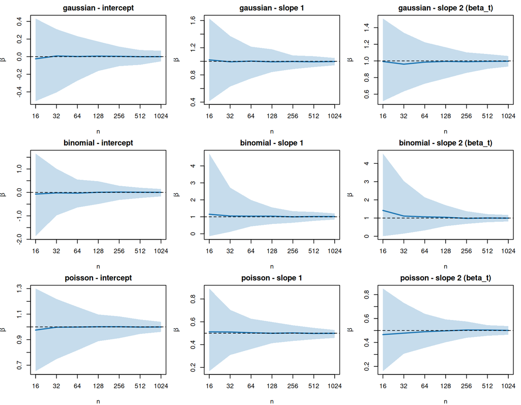

```r
band <- grDevices::adjustcolor(MPL[1], alpha.f = 0.25)
op <- par(mfrow = c(3, 3), mar = c(4, 4, 2, 1))
for (fam in names(sim)) {
  for (j in seq_along(beta)) {
    q <- apply(sim[[fam]]$est[, , j], 1, quantile,
               c(0.025, 0.5, 0.975), na.rm = TRUE)
    plot(n_seq, q[2, ], log = "x", type = "n", ylim = range(q),
         xaxt = "n", xlab = "n", ylab = expression(hat(beta)),
         main = paste(fam, "-", coef_names[j]))
    axis(1, at = n_seq)
    polygon(c(n_seq, rev(n_seq)), c(q[1, ], rev(q[3, ])), col = band,
            border = NA)
    lines(n_seq, q[2, ], col = MPL[1], lwd = 2)
    abline(h = beta_true[[fam]][j], lty = 2)
  }
}
```

```r
par(op)
```

## Posterior SD against the spread

A single fit cannot show the spread above. It reports the posterior SD instead. The ratio below divides the mean posterior SD by the SD of $\hat\beta$ over the 200 data sets. A ratio near 1 means that one fit reports its own noise correctly.

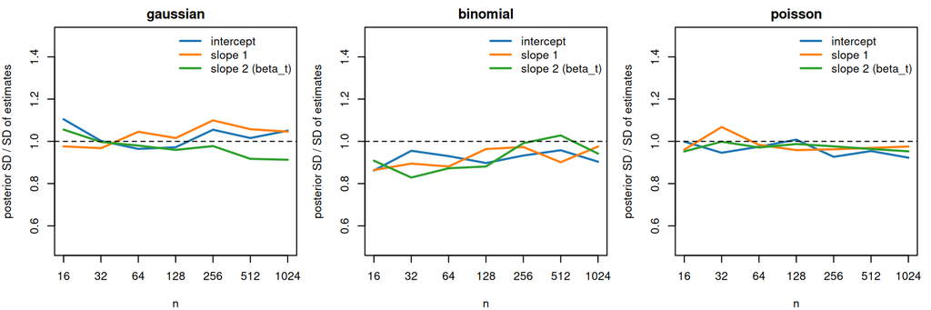

```r
op <- par(mfrow = c(1, 3), mar = c(4, 4, 2, 1))
for (fam in names(sim)) {
  ratio <- sapply(seq_along(beta), function(j) {
    rowMeans(sim[[fam]]$sd[, , j], na.rm = TRUE) /
      apply(sim[[fam]]$est[, , j], 1, sd, na.rm = TRUE)
  })
  matplot(n_seq, ratio, log = "x", type = "l", lty = 1, lwd = 2,
          col = MPL[seq_along(beta)], ylim = c(0.5, 1.5), xaxt = "n",
          xlab = "n", ylab = "posterior SD / SD of estimates", main = fam)
  axis(1, at = n_seq)
  abline(h = 1, lty = 2)
  legend("topright", coef_names, col = MPL[seq_along(beta)], lwd = 2,
         bty = "n")
}
```

```r
par(op)
```